# MEG304:: Jupyter Notebook::Practice sample for W10:MID test

> Date: 2021-Nov-20 R00.  
> suggested practice steps:
> > 1. Run it without any modification.
> > 2. check out all of markdown cells --See what they said.
> > 3. Step-by-step Run each cell to get started to learn python coding & its output.
> > 4. take snapshots for some valueable results, and name them as outFIG1.png, outFIG2.png ...
> > 5. Add (Insert!!) your own results (outFIG1.png , outFIGx.png) as new cells in proper sequences.
> > 6. Download the full runnable notebook file with the results as .HTML file (&export it as PDF file)

NOTE:After practice, REMOVE ALL of the ABOVE STEPS, clear it up to make a clean report:: YOUR VERSION.

### PC seat Number : 11

> Rev:. 0.1 Date: 2021-Nov-X

## DEMO 1 Section -- How to solve the given problem

### GOAL : Define a function to do the job1 : Enter two numbers and print its SUM result.

```python
### Sample function  1 -  define a function to do the job1 : add two numbers and print its result.
```

```python
# Add you own AddTwoNums function like this
def AddTwoNumbers ( a1, b1):
    return a1+b1
```

```python
# if added this new function :
def printNum(num, stuID):
    print(f"MEG304:: {stuID}  favourite number is {num}")
```

```python
#TODO - revise the following lines if  needed.
#printNum(7)
#printNum(14)
#printNum(2)
```

```python
## Job1 - start to prompt user to enter two numbers, expect them as two STRINGs
aa1, bb1 =input("Enter Two numbers with COMMA , like this (a1,b1) :").split(",")
```

```
Enter Two numbers with COMMA , like this (a1,b1) :230, 456
```

```python
print(aa1, bb1)
print (type(aa1))
```

```
230  456
<class 'str'>
```

```python
a1 = int(aa1)
b1 = int(bb1)
myStuID="Stu101_2021"  ## change it as your own Student ID
ans1 = AddTwoNumbers( a1, b1)
printNum(ans1,myStuID )
```

```
MEG304:: Stu101_2021  favourite number is 686
```

### OK. Got the correct result ? !

#### (Optional ) and take the snapshot to make up a MD cell below:

> tips: check out the [Add Local Image] section to learn what steps needed.

### DEMO1 Result snapshot ::outFIG1.png

> assumed that the snapshot is at subfolder IMG

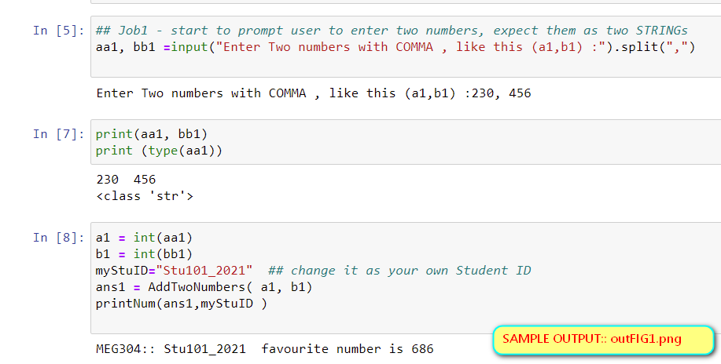

```python
## TODO- template ( change the outfile name)
# A sample code to display the marked image file (at local subfolder )
from IPython import display

# display.Image("./img/FIG1-Addimage.png")
display.Image("./img/outFIG1.png")
```

### End of DEMO 1

## Practice -- (Just do it to review the essential python )

# Notebook 0 - Programming with Python recap

This course assumes that you have knowledge of basic Python (equivalent to having attended the Introduction to Python course run by Information Services).

Just to make sure we are all on the same page, this notebook will serve as a recap of basic Python functionality.

- Add Local Image
- Types
- Arithmetic operations
- Boolean logic
- Printing
- Lists
- If-Else
- Loops
- Functions
- Exercises

You are intended to skim over this notebook and do the exercises at the end.

You can use this notebook as a reference for the rest of the course.

# Add Local Image

you can add a local image file here by the following statements

HowToDo : at CODE cell, add the following lines below, and give the proper filename in the second line. note: the picture file is at the subolder "img", so the relative addressing is needed to indicate its location.

line1: from IPython import display line2: display.Image(./img/Addimage.png)

```python
# A sample code to display the marked image file (at local subfolder )
from IPython import display

# display.Image("./img/FIG1-Addimage.png")
display.Image("./img/FIG00.png")
```

[output not shown]

```python
# python cell - display another image
print(" python cell - display another image with display.Image(afilename)  ")
display.Image("./img/FIG01.png")
```

[output not shown]

# Types

| Type | Declaration | Example | Usage |
| --- | --- | --- | --- |
| Integer | int | `x = 124` | Numbers without decimal point |
| Float | float | `x = 124.56` | Numbers with decimcal point |
| String | str | `x = "Hello world"` | Used for text |
| Boolean | bool | `x = True` or `x = False` | Used for conditional statements |
| NoneType | None | `x = None` | Whenever you want an empty variable |

You can convert from one type to another:

```python
x = 10    # This is an integer
y = "20"  # This is a string
x + int(y)
```

You can find the type of a variable using the `type()` function:

```python
var = 13.4
type(var)
```

# Arithmetical operators

Python supports a range of different arithmetical operators:

| Symbol | Task Performed | Example | Result |
| --- | --- | --- | --- |
| + | Addition | 4 + 3 | 7 |
| - | Subtraction | 4 - 3 | 1 |
| / | Division | 7 / 2 | 3.5 |
| % | Mod | 7 % 2 | 1 |
| * | Multiplication | 4 * 3 | 12 |
| // | Floor division | 7 // 2 | 3 |
| ** | Power of | 7 ** 2 | 49 |

```python
16 ** 2 / 4
```

# Boolean logic

| Operator | Output |
| --- | --- |
| x == y | True if x and y have the same value |
| x != y | True if x and y don't have the same value |
| x < y | True if x is less than y |
| x > y | True if x is more than y |
| x <= y | True if x is less than or equal to y |
| x >= y | True if x is more than or equal to y |

Make note that these operators return Boolean values (ie. `True` or `False`). Naturally, if the operations don't return `True`, they will return `False`. Let's try some of them out:

```python
x = 5       # assign 5 to the variable x
x == 5      # check if value of x is 5
```

```python
x > 7
```

That is nice! How can we extend this to link multiple combinations like that? Luckily, Python offers the usual set of **logical operations**:

| Operation | Result |
| --- | --- |
| x or y | True if at least on is True |
| x and y | True only if both are True |
| not x | True only if x is False |

With this, we can now chain different boolean operations:

```python
# check if x is divisible by both 2 and 3
x = 42
( x % 2 == 0 ) and ( x % 3 == 0)
```

# Printing

Output text to the user of the program

```python
print("Python is powerful!")
```

```python
x = "Python is powerful"
y = " and versatile!"
print(x + y)
```

```python
str1 = "The string has"
str2 = 76
str3 = "methods!"
print(str1, str2, str3)
```

Furthermore, there is also a way to insert variables inbetween text using placeholders like `%d` which stands for decimal. As seen from the code cell below, this is an extremely compact and easy way to print.

```python
num = 12
print("You can also include a number like %d like this." %num)
```

```python
x = """To include
multiple lines
you have to do this"""
y ="or you can also\ninclude the special\ncharacter `\\n` between lines"
print(x)
print(y)
```

# Lists

Probably the most commonly used data structure in Python. Lists simply group multiple variables together.

```python
fruits = ["apple", "orange", "tomato", "banana"]  # a list of strings
print(type(fruits))
print(fruits)
```

```python
print(fruits[0])
print(fruits[2])
print(fruits[-1])
print(len(fruits))
```

You can modify existing lists as:

```python
fruits.append("lime")    # add new item to list
print(fruits)
fruits.append("orange")
print(fruits)
fruits.remove("orange")  # remove orange from list
print(fruits)
```

That seems useful! Can we do the same with integers? Python actually offers various functions for generating numerical lists. The most useful out of which is:

```python
nums = list(range(10))
print(nums)
```

You can also get only a part of a list you have already created. This is called **slicing** and can be done in various different ways:

```python
print(nums[0:3])
print(nums[4:])
print(nums[-1])
print(nums[::-1])
```

# If Else

The statement after `if` must evaluate to a Boolean value (`True` or `False`), if it is `True` then we execute the code between the `if` and `else` statements and skip the code after the else statement. If the Boolean expression after `if` evaluates to `False` then we skip the code between `if` and `else` and execute only the code after `else`.

```python
x = True
if x:
    print("Executing if")
else:
    print("Executing else")
print("Prints regardless of the outcome of the if-else block")
```

Try changing the value of x to `False`.

if-else statements can also be extended with `elif` which as implied combines both else + if = elif. This is useful if you want to have multiple conditions for example:

Let us illustrate this in an elaborate example. Imagine you have purchased a stock and are looking to make a profit out of it.

```python
purchasePrice = float(input("Price at which you have purchased bitcoins: "))
currentPrice = float(input("Current price of the bitcoins: "))

if currentPrice < purchasePrice*0.9:
    print("Not a good idea to sell your bitcoins now.")
    print("You will lose", purchasePrice - currentPrice, "£ per bitcoin.")
elif currentPrice > purchasePrice*1.2:
    print("You will make", currentPrice - purchasePrice, "£ per bitcoin.")
else:
    print("Not worth selling right now.")
```

# Loops

## for

Generally useful whenever you want to iterate over a list (or other data structure) of items and apply the same operation to all items within it. In general, `for` loops look like this and have indentation just like if-else statements:

```python
fruitList = ["apple", "orange", "tomate", "banana"]
for fruit in fruitList:
    print("The fruit", fruit, "has index", fruitList.index(fruit))
```

```python
numbers = range(10)
for num in numbers:
    squared = num ** 2
    print(num, "squared is", squared)
```

## while

Another useful loop which is a bit less controllable. It executes over and over until its condition becomes false. For example, we can make a loop that executes 5 times and then stops.

```python
n = 0
while n < 5:
    print("Executing while loop")
    n = n + 1

print("Finished while loop")
```

# Functions

Also referred to as methods, functions are effectively small programs that take in arguments(ie. inputs) and return values(outputs).

Functions are an incredibly useful concept since they allow us to package functionality in a convenient and easy to read manner and reproduce the same result without having to write it again and again. A quick example:

```python
def printNum(num):
    print("My favourite number is", num)

printNum(7)
printNum(14)
printNum(2)
```

**Rule of thumb** - if you are planning on using very similar code more than once, it may be wortwhile writing it as a reusable function.

Here's also an example of a function that rounds a number:

```python
def roundNum(num):
    remainder = num % 1
    if remainder < 0.5:
        return num - remainder
    else:
        return num + (1 - remainder)

# Will it work?
x = roundNum(3.4)
print (x)

y = roundNum(7.7)
print(y)

z = roundNum(9.2)
print(z)
```

# Exercises

Now we have a couple of exercises to let you put your skills into practice.

## Exercise 1: Fibonacci

Create a function `fibonacci()` which takes an integer `num` as an input and returns a list of the first `num` fibonacci numbers.

Eg.

Input: `8`

Output: `[1, 1, 2, 3, 5, 8, 13, 21]`

*Hint: You might want to recall [fibonacci numbers](https://en.wikipedia.org/wiki/Fibonacci_number)*

```python
def fibonacci(num):
    # [ WRITE YOUR CODE HERE ]
```

Check your answer by running the code cell below.

```python
################ Checking code ########################
# Please don't edit this code
newList = fibonacci(10)
if newList == [1, 1, 2, 3, 5, 8, 13, 21, 34, 55]:
    print("Success!")
else:
    print("Error! Your function returned")
    print(newList)
```

## Exercise 2: Guessing Game

Ask the user to input a number within the range from 0 to 100 inclusive, and then have the program guess it. After each guess, the user must input whether it was too high, too low or the correct number (a *clue*). In the end, the program must always guess the user's number and it must print out the number of guesses it needed.

It may be useful to note that

- You can use `random.randint(0,100)` to generate the random number, but don't forget to also import the `random` package via `import random`
- You can use `input()` to ask the user for a number

*Hint: How can you update the range of your random number generator based on the user's clue?*